# Boston Housing Median Value Prediction

BANA 7047 Data Mining II

Straight, Kaitlyn | M17348257 | Section 001

2026-04-23

# 1 Introduction & Problem Statement

The **Boston Housing dataset**, originally studied by Harrison & Rubinfeld (1978), contains 506 observations on median home values (`medv`, scaled by $1000’s) across Boston-area neighborhoods, along with 13 socioeconomic and structural predictors. The data were collected from the 1970 U.S. Census and originally compiled to study the relationship between air quality and housing prices in the Boston metropolitan area.

**Goal:** Predict median home value (`medv`) using a variety of supervised machine learning models, compare their predictive accuracy, and identify the key drivers of housing prices in the Boston area.

**Predictors include:**

| Variable | Description |
| --- | --- |
| `crim` | Per capita crime rate by town |
| `zn` | Proportion of residential land zoned for large lots |
| `indus` | Proportion of industrial (non-retail) business acres |
| `chas` | Charles River dummy (1 if property bounds river) |
| `nox` | Nitrogen oxide concentration (parts per 10 million) |
| `rm` | Average number of rooms per dwelling |
| `age` | Proportion of owner-occupied units built before 1940 |
| `dis` | Weighted distance to Boston employment centers |
| `rad` | Index of accessibility to radial highways |
| `tax` | Full-value property tax rate per $10,000 |
| `ptratio` | Pupil-teacher ratio by town |
| `black` | $1000(B_k - 0.63)^2$ where $B_k$ is proportion Black residents |
| `lstat` | % lower-status population |

**Models Applied:** Linear Regression, Regression Tree, k-Nearest Neighbor (k-NN), Random Forests, Boosting, Generalized Additive Model (GAM), and Neural Networks.

**Train/Test Split:** A random 80/20 split is used consistently throughout, with `set.seed(17348257)`.

# 2 Data Overview & Exploratory Data Analysis

```
## Rows: 506  | Columns: 14
```

```
##       crim                zn             indus            chas
##  Min.   : 0.00632   Min.   :  0.00   Min.   : 0.46   Min.   :0.00000
##  1st Qu.: 0.08205   1st Qu.:  0.00   1st Qu.: 5.19   1st Qu.:0.00000
##  Median : 0.25651   Median :  0.00   Median : 9.69   Median :0.00000
##  Mean   : 3.61352   Mean   : 11.36   Mean   :11.14   Mean   :0.06917
##  3rd Qu.: 3.67708   3rd Qu.: 12.50   3rd Qu.:18.10   3rd Qu.:0.00000
##  Max.   :88.97620   Max.   :100.00   Max.   :27.74   Max.   :1.00000
##       nox               rm             age              dis
##  Min.   :0.3850   Min.   :3.561   Min.   :  2.90   Min.   : 1.130
##  1st Qu.:0.4490   1st Qu.:5.886   1st Qu.: 45.02   1st Qu.: 2.100
##  Median :0.5380   Median :6.208   Median : 77.50   Median : 3.207
##  Mean   :0.5547   Mean   :6.285   Mean   : 68.57   Mean   : 3.795
##  3rd Qu.:0.6240   3rd Qu.:6.623   3rd Qu.: 94.08   3rd Qu.: 5.188
##  Max.   :0.8710   Max.   :8.780   Max.   :100.00   Max.   :12.127
##       rad              tax           ptratio          black
##  Min.   : 1.000   Min.   :187.0   Min.   :12.60   Min.   :  0.32
##  1st Qu.: 4.000   1st Qu.:279.0   1st Qu.:17.40   1st Qu.:375.38
##  Median : 5.000   Median :330.0   Median :19.05   Median :391.44
##  Mean   : 9.549   Mean   :408.2   Mean   :18.46   Mean   :356.67
##  3rd Qu.:24.000   3rd Qu.:666.0   3rd Qu.:20.20   3rd Qu.:396.23
##  Max.   :24.000   Max.   :711.0   Max.   :22.00   Max.   :396.90
##      lstat            medv
##  Min.   : 1.73   Min.   : 5.00
##  1st Qu.: 6.95   1st Qu.:17.02
##  Median :11.36   Median :21.20
##  Mean   :12.65   Mean   :22.53
##  3rd Qu.:16.95   3rd Qu.:25.00
##  Max.   :37.97   Max.   :50.00
```

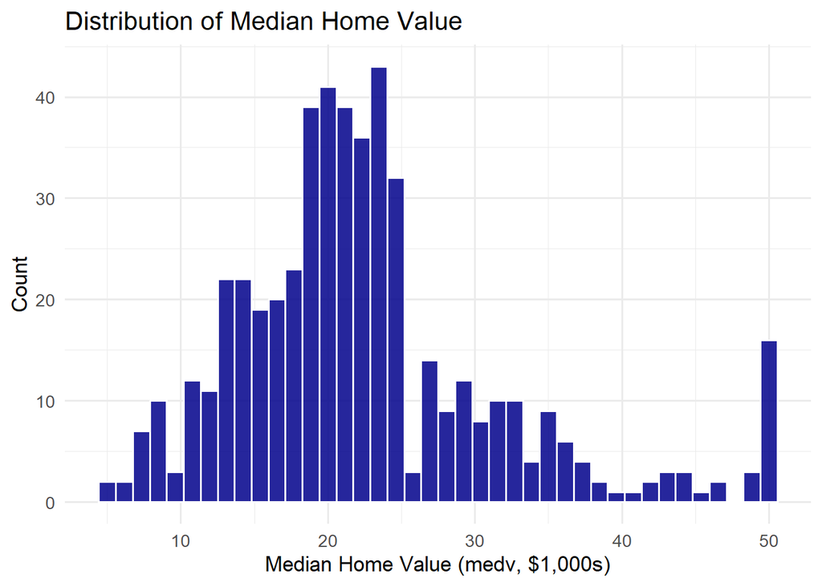

Figure 1: Distribution of Median Home Value. The response variable is right-skewed with a spike at $50K (likely a censoring cap).

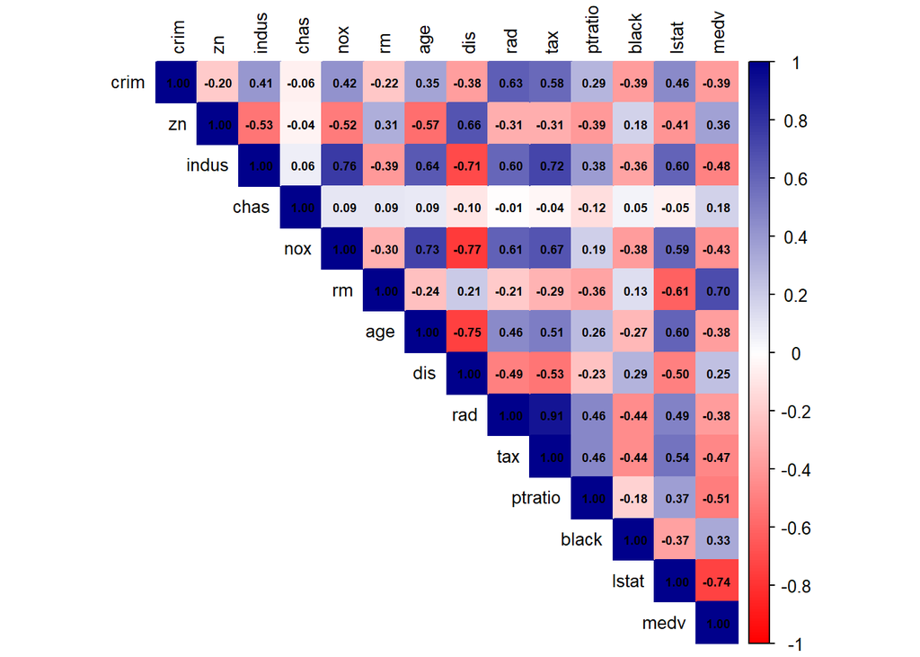

Figure 2: Correlation matrix of all Boston Housing variables. lstat and rm display the strongest correlations with medv.

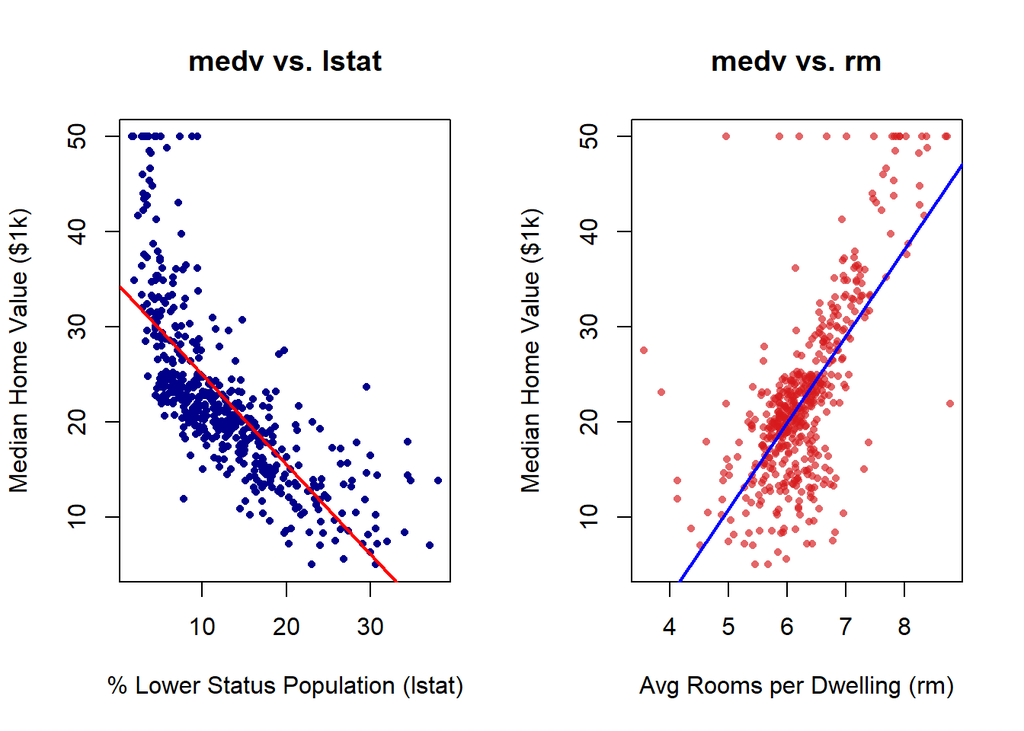

Figure 3: Median Value vs. lstat and rm — the two strongest predictors. Larger lstat (lower-status population) strongly reduces home value; more rooms (rm) increases value.

# 3 Train/Test Split

All models use an 80/20 split.

```
## Training observations: 404
## Testing observations:  102
```

# 4 Model 1: Linear Regression with Variable Selection

**Overview:** Ordinary least squares (OLS) regression estimates a linear relationship between `medv` and the predictors. Variable selection via Stepwise AIC is used to remove predictors that do not contribute significantly (here, `age` and `indus` are removed).

```
## Start:  AIC=1237.66
## medv ~ crim + zn + indus + chas + nox + rm + age + dis + rad +
##     tax + ptratio + black + lstat
##
##           Df Sum of Sq    RSS    AIC
## - indus    1      1.45 8069.1 1235.7
## - age      1      1.88 8069.6 1235.8
## <none>                 8067.7 1237.7
## - crim     1    121.13 8188.8 1241.7
## - zn       1    171.52 8239.2 1244.2
## - tax      1    177.46 8245.1 1244.5
## - chas     1    195.02 8262.7 1245.3
## - nox      1    271.91 8339.6 1249.0
## - black    1    291.40 8359.1 1250.0
## - rad      1    296.99 8364.7 1250.3
## - dis      1    817.11 8884.8 1274.6
## - ptratio  1   1107.78 9175.5 1287.6
## - lstat    1   1597.18 9664.9 1308.6
## - rm       1   1625.62 9693.3 1309.8
##
## Step:  AIC=1235.73
## medv ~ crim + zn + chas + nox + rm + age + dis + rad + tax +
##     ptratio + black + lstat
##
##           Df Sum of Sq    RSS    AIC
## - age      1      1.87 8071.0 1233.8
## <none>                 8069.1 1235.7
## + indus    1      1.45 8067.7 1237.7
## - crim     1    122.17 8191.3 1239.8
## - zn       1    170.06 8239.2 1242.2
## - chas     1    199.56 8268.7 1243.6
## - tax      1    203.78 8272.9 1243.8
## - nox      1    279.96 8349.1 1247.5
## - black    1    290.20 8359.3 1248.0
## - rad      1    314.45 8383.6 1249.2
## - dis      1    881.70 8950.8 1275.6
## - ptratio  1   1125.68 9194.8 1286.5
## - lstat    1   1600.56 9669.7 1306.8
## - rm       1   1627.07 9696.2 1307.9
##
## Step:  AIC=1233.83
## medv ~ crim + zn + chas + nox + rm + dis + rad + tax + ptratio +
##     black + lstat
##
##           Df Sum of Sq    RSS    AIC
## <none>                 8071.0 1233.8
## + age      1      1.87 8069.1 1235.7
## + indus    1      1.45 8069.6 1235.8
## - crim     1    122.25 8193.3 1237.9
## - zn       1    175.94 8247.0 1240.5
## - chas     1    198.65 8269.7 1241.7
## - tax      1    205.30 8276.3 1242.0
## - black    1    288.59 8359.6 1246.0
## - nox      1    315.78 8386.8 1247.3
## - rad      1    320.45 8391.5 1247.6
## - dis      1    947.02 9018.0 1276.7
## - ptratio  1   1141.70 9212.7 1285.3
## - rm       1   1687.84 9758.8 1308.5
## - lstat    1   1865.11 9936.1 1315.8
```

```
##
## Call:
## lm(formula = medv ~ crim + zn + chas + nox + rm + dis + rad +
##     tax + ptratio + black + lstat, data = Boston_train)
##
## Residuals:
##      Min       1Q   Median       3Q      Max
## -15.8233  -2.5117  -0.5265   1.8048  25.6653
##
## Coefficients:
##               Estimate Std. Error t value Pr(>|t|)
## (Intercept)  33.353179   5.345954   6.239 1.14e-09 ***
## crim         -0.087000   0.035704  -2.437 0.015266 *
## zn            0.041015   0.014031   2.923 0.003665 **
## chas          3.002514   0.966624   3.106 0.002033 **
## nox         -14.945295   3.816217  -3.916 0.000106 ***
## rm            3.993889   0.441114   9.054  < 2e-16 ***
## dis          -1.349643   0.199003  -6.782 4.38e-11 ***
## rad           0.257078   0.065164   3.945 9.45e-05 ***
## tax          -0.010817   0.003426  -3.158 0.001713 **
## ptratio      -1.010473   0.135697  -7.447 6.15e-13 ***
## black         0.011082   0.002960   3.744 0.000208 ***
## lstat        -0.487374   0.051207  -9.518  < 2e-16 ***
## ---
## Signif. codes:  0 '***' 0.001 '**' 0.01 '*' 0.05 '.' 0.1 ' ' 1
##
## Residual standard error: 4.538 on 392 degrees of freedom
## Multiple R-squared:  0.7573, Adjusted R-squared:  0.7505
## F-statistic: 111.2 on 11 and 392 DF,  p-value: < 2.2e-16
```

```
##
## Call:
## lm(formula = medv ~ . - indus - age, data = Boston_train)
##
## Residuals:
##      Min       1Q   Median       3Q      Max
## -15.8233  -2.5117  -0.5265   1.8048  25.6653
##
## Coefficients:
##               Estimate Std. Error t value Pr(>|t|)
## (Intercept)  33.353179   5.345954   6.239 1.14e-09 ***
## crim         -0.087000   0.035704  -2.437 0.015266 *
## zn            0.041015   0.014031   2.923 0.003665 **
## chas          3.002514   0.966624   3.106 0.002033 **
## nox         -14.945295   3.816217  -3.916 0.000106 ***
## rm            3.993889   0.441114   9.054  < 2e-16 ***
## dis          -1.349643   0.199003  -6.782 4.38e-11 ***
## rad           0.257078   0.065164   3.945 9.45e-05 ***
## tax          -0.010817   0.003426  -3.158 0.001713 **
## ptratio      -1.010473   0.135697  -7.447 6.15e-13 ***
## black         0.011082   0.002960   3.744 0.000208 ***
## lstat        -0.487374   0.051207  -9.518  < 2e-16 ***
## ---
## Signif. codes:  0 '***' 0.001 '**' 0.01 '*' 0.05 '.' 0.1 ' ' 1
##
## Residual standard error: 4.538 on 392 degrees of freedom
## Multiple R-squared:  0.7573, Adjusted R-squared:  0.7505
## F-statistic: 111.2 on 11 and 392 DF,  p-value: < 2.2e-16
```

```
## Linear Model  |  In-sample ASE: 19.98  |  Out-of-sample MSPE: 30.19
```

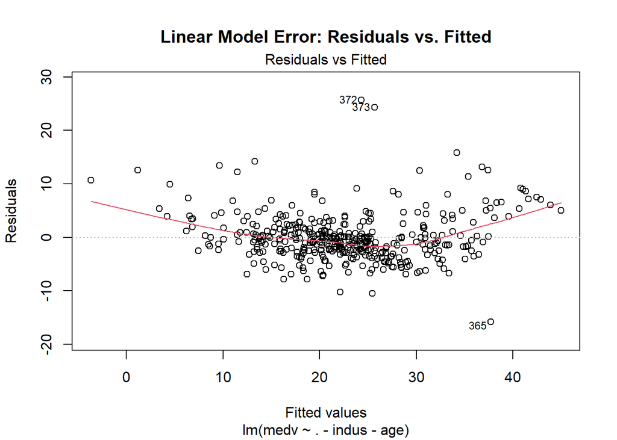

Figure 4: Residuals vs. Fitted for the linear model. A nonlinear pattern in the residuals suggests the true relationship may not be fully captured by a linear model.

**Interpretation:** All retained predictors are significant (p < 0.05). `lstat` (negative) and `rm` (positive) have the largest effect sizes. The residual plot’s LOESS trendline reveals nonlinearity, indicating that the model tends to underestimate for both low-value and high-value homes. The widening spread of residuals at higher fitted values indicates mild heteroscedasticity, violating the OLS assumption of constant error variance and suggesting the model’s predictions are less reliable at the extremes. Outlier observations 372, 373, and 365 likely reflect the $50K censoring cap, producing extreme residuals where true values exceeded the recorded ceiling. Together, these patterns suggest the use of more flexible models in subsequent sections.

# 5 Model 2: Regression Tree with Pruning

**Overview:**A regression tree splits the data into groups based on yes/no cutoffs on predictor values in order to find the average median home value of each group. This process iterates to create a tree of if/then rules that carve the data into increasingly specific subgroups. Pruning the tree back to the optimal CP value prevents overfitting by removing splits that don’t meaningfully improve prediction on new data.

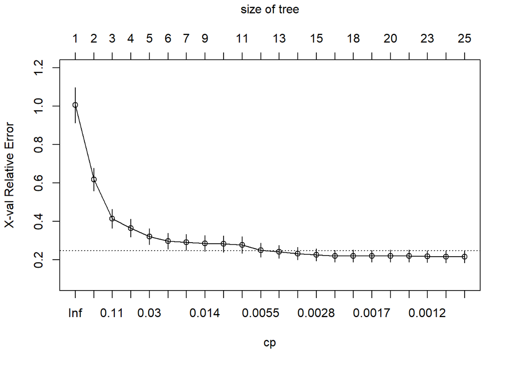

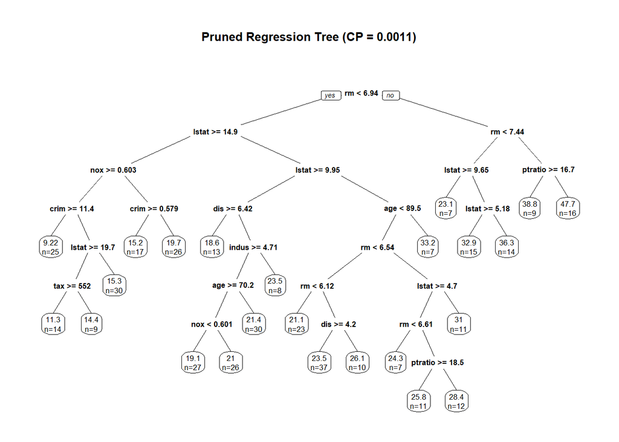

Figure 6: Pruned regression tree. Splits on lstat and rm dominate, consistent with the linear model.

```
## Regression Tree  |  In-sample ASE: 10.03  |  Out-of-sample MSPE: 19.42
```

**Interpretation:** The pruned tree makes splits primarily on `lstat` and `rm`, confirming they are the most important partitioning variables. Trees are highly interpretable but can underperform ensemble methods.

# 6 Model 3: k-Nearest Neighbor (k-NN) Regression

**Overview:** k-NN predicts a new observation’s response as the average of its k nearest neighbors in predictor space. Predictors are scaled to [0,1] using training-data min/max so no single variable dominates due to scale. Optimal k is chosen by minimizing RMSE on a withheld validation set.

```
## Optimal k: 6
```

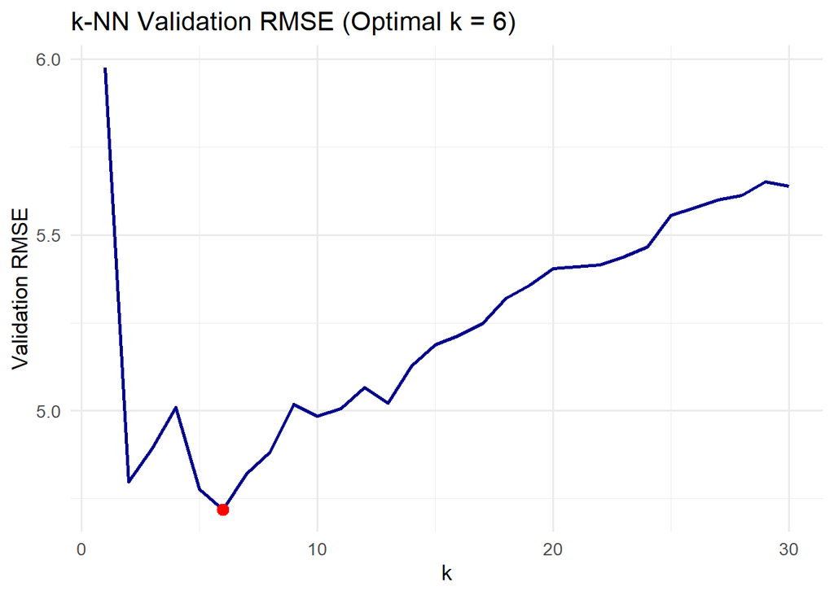

Figure 7: Validation RMSE for k = 1 to 30. The optimal k minimizes RMSE on the validation set.

```
## k-NN (k = 6 )  |  In-sample ASE: 16.52  |  Out-of-sample MSPE: 29.92
```

**Interpretation:** k-NN is a non-parametric approach that makes no assumptions about functional form. Its performance depends on proper scaling and k selection. It can struggle in high-dimensional settings but performs reasonably here with 13 predictors.

# 7 Model 4: Random Forests

**Overview:** Random forests build many independent trees by first bootstrapping the training data and considering only a random subset of predictors (`mtry`) at each split. Predictions are averaged across all trees, greatly reducing variance compared to a single tree. The default `mtry = p/3 ≈ 4` is used for regression.

```
##
## Call:
##  randomForest(formula = medv ~ ., data = Boston_train, importance = TRUE,      ntree = 500)
##                Type of random forest: regression
##                      Number of trees: 500
## No. of variables tried at each split: 4
##
##           Mean of squared residuals: 10.3554
##                     % Var explained: 87.42
```

```
## Random Forests  |  In-sample ASE: 2.07  |  Out-of-sample MSPE: 14.9
```

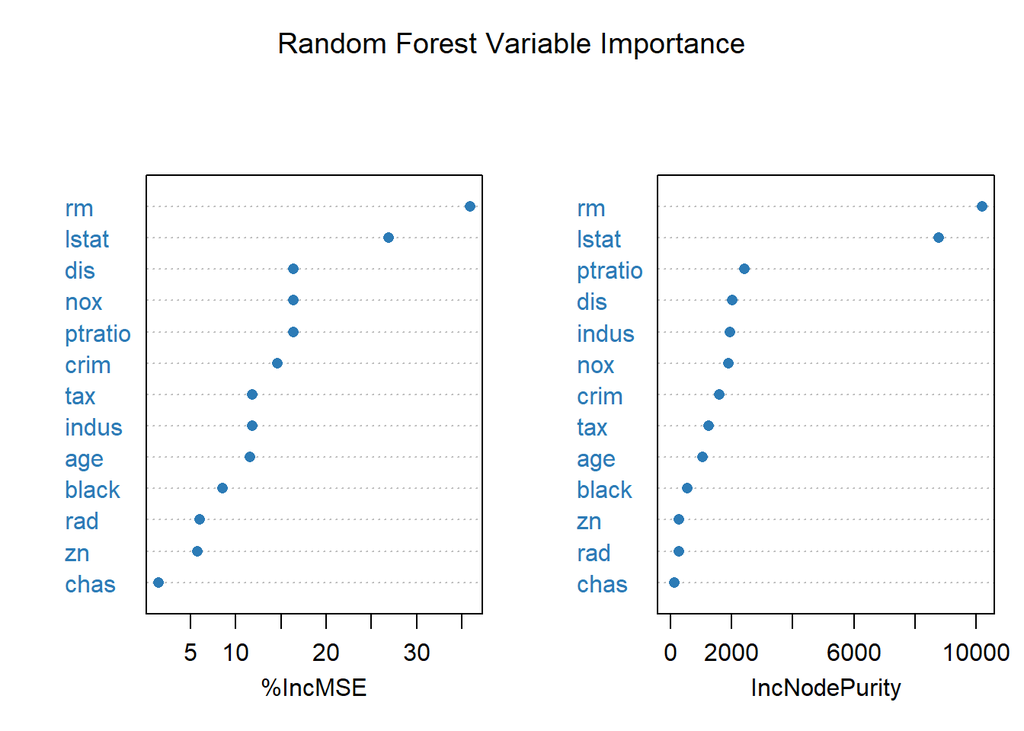

Figure 8: Variable importance from Random Forests. %IncMSE measures how much MSPE increases when a variable is randomly shuffled. IncNodePurity measures how much each variable reduces the variance within tree nodes. Larger values indicate variables have large effects on MSE and tree nodes. lstat and rm are by far the most important predictors.

**Interpretation:** Random Forests dramatically reduce variance over a single tree (MSPE 14.9 vs. 19.42 for Random Forest and Regression Tree, respectively). `rm` and `lstat` are confirmed as the top two predictors. `dis` (distance to employment) and `nox` (air quality) also rank highly, suggesting location and environmental factors matter substantially.

# 8 Model 5: Boosting

**Overview:** Boosting (via `gbm`) fits trees sequentially, with each iteration correcting the residual errors of the previous model. Key tuning parameters: number of trees (10,000), shrinkage/learning rate (0.01), and interaction depth (8). The model is built on training data only.

```
## Boosting  |  In-sample ASE: 0.02  |  Out-of-sample MSPE: 9.66
```

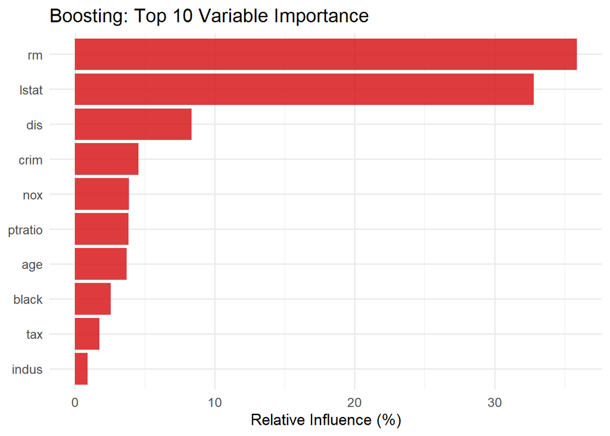

Figure 9: Relative variable importance from Boosting (GBM). rm leads, followed by lstat, dis, and crim.

**Interpretation:** Boosting tends to achieve among the lowest MSPE values of all methods due to its iterative correction strategy. The variable importance ranking closely mirrors that of random forests, reinforcing which predictors matter most.

# 9 Model 6: Generalized Additive Model (GAM)

**Overview:** A GAM extends linear regression by allowing smooth, nonlinear functions of each predictor via splines, while maintaining additive structure and interpretability. Variables `zn` and `age` are kept linear (their smooths appeared approximately linear in exploratory fits).

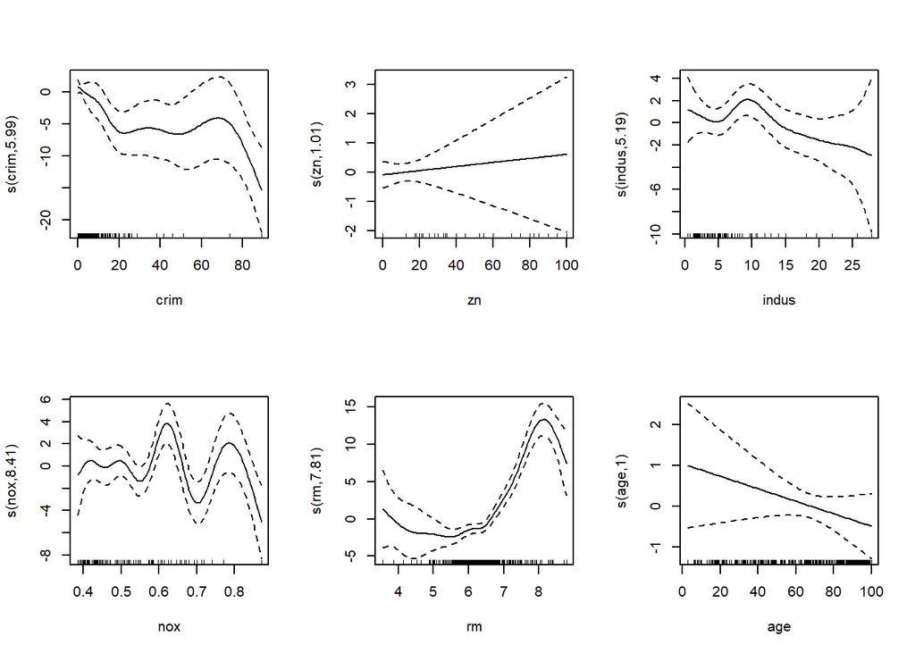

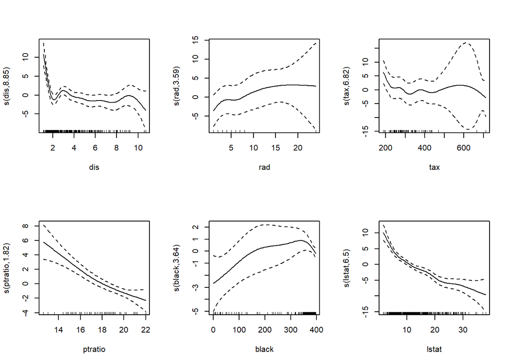

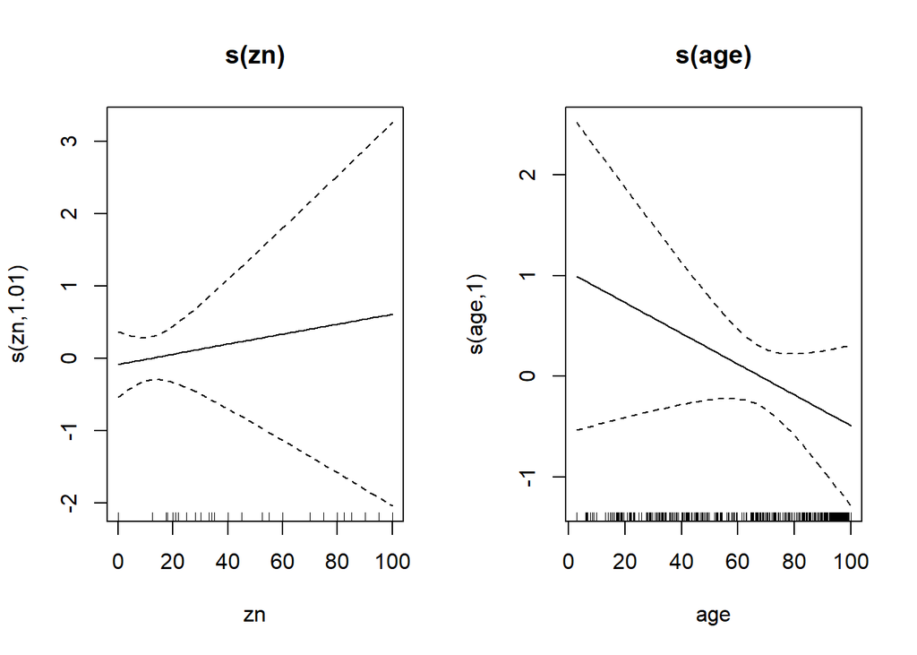

```
##
## Family: gaussian
## Link function: identity
##
## Formula:
## medv ~ s(crim) + zn + s(indus) + chas + s(nox) + s(rm) + age +
##     s(dis) + rad + s(tax) + s(ptratio) + s(black) + s(lstat)
##
## Parametric coefficients:
##              Estimate Std. Error t value Pr(>|t|)
## (Intercept) 19.891187   1.590805  12.504  < 2e-16 ***
## zn           0.005399   0.015217   0.355  0.72294
## chas         1.110339   0.714642   1.554  0.12118
## age         -0.013550   0.011843  -1.144  0.25336
## rad          0.380810   0.145132   2.624  0.00908 **
## ---
## Signif. codes:  0 '***' 0.001 '**' 0.01 '*' 0.05 '.' 0.1 ' ' 1
##
## Approximate significance of smooth terms:
##              edf Ref.df      F  p-value
## s(crim)    5.757  6.866  6.612 9.37e-07 ***
## s(indus)   6.626  7.589  2.487   0.0153 *
## s(nox)     8.660  8.935 11.208  < 2e-16 ***
## s(rm)      7.882  8.663 20.359  < 2e-16 ***
## s(dis)     8.776  8.979  6.931  < 2e-16 ***
## s(tax)     6.755  7.734  5.429 3.38e-06 ***
## s(ptratio) 1.585  1.958 19.307  < 2e-16 ***
## s(black)   2.354  2.901  3.017   0.0385 *
## s(lstat)   6.526  7.675 16.400  < 2e-16 ***
## ---
## Signif. codes:  0 '***' 0.001 '**' 0.01 '*' 0.05 '.' 0.1 ' ' 1
##
## R-sq.(adj) =  0.888   Deviance explained = 90.4%
## GCV = 10.899  Scale est. = 9.2825    n = 404
```

```
## GAM  |  In-sample ASE: 7.91  |  Out-of-sample MSPE: 12.26
```

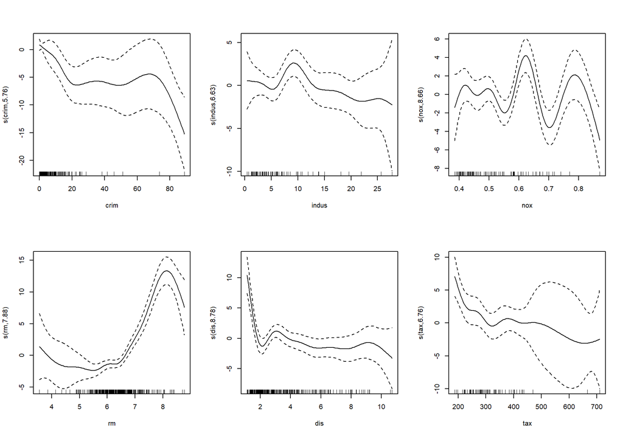

Figure 10: GAM partial effects for selected predictors. Curves show the nonlinear relationships between each predictor and medv, holding others constant. Note the sharp effect of lstat and the plateau-then-rise in rm.

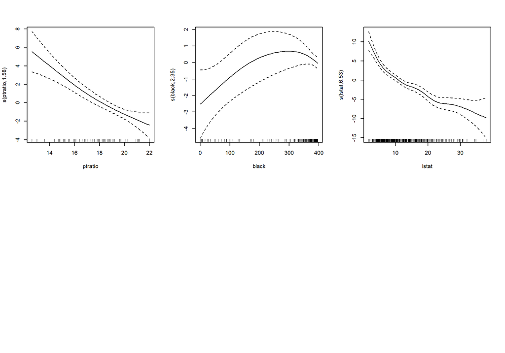

Figure 10: GAM partial effects for selected predictors. Curves show the nonlinear relationships between each predictor and medv, holding others constant. Note the sharp effect of lstat and the plateau-then-rise in rm.

**Interpretation:** The GAM captures clear nonlinear relationships that the linear model cannot, particularly for `lstat`, `rm`, and `nox`. The smooth terms are all statistically significant, confirming that a linear model was an oversimplification. GAM maintains a strong balance between flexibility and interpretability.

# 10 Model 7: Neural Networks

**Overview:** A neural network passes inputs through hidden layers of neurons, applying weighted combinations of the predictors and nonlinear transformations in order to detect more complex patterns within the data. The network minimizes error through iteration, continually adjusting its weights via backpropogation. Scaling both predictors and the response variable `medv` to [0,1] is essential for training stability, as differences in variable scales can destabilize the weight-adjustment process.

**Architecture:** Hidden layers = (5), `linear.output = TRUE` for regression.

```
## Neural Network (scaled, hidden=5)  |  In-sample ASE: 5.27  |  Out-of-sample MSPE: 8.71
```

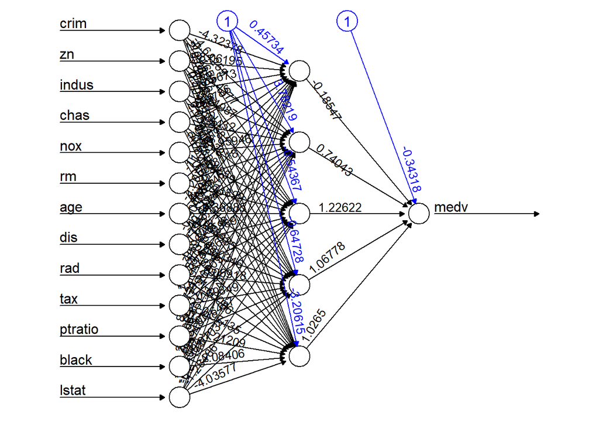

Figure 11: Neural network architecture diagram (scaled model, 1 hidden layer with 5 nodes). Each connection has a learned weight; the network transforms the 13 inputs through the hidden layer to predict medv.

# 11 Model Comparison Summary

## 11.1 Summary Table

*Table 1: In-sample Average Squared Error (ASE) and out-of-sample Mean Squared Prediction Error (MSPE) for all models. A random 80/20 train/test split is used with `set.seed(17348257)`.*

Table 1: Model Comparison — ASE (in-sample) and MSPE (out-of-sample). Random seed = 17348257, 80% training / 20% testing.

| Model | In-Sample ASE | Out-of-Sample MSPE |
| --- | --- | --- |
| Linear Regression (no indus, age) | 19.98 | 30.19 |
| Regression Tree (pruned) | 10.03 | 19.42 |
| k-NN (k = 6, scaled X) | 16.52 | 29.92 |
| Random Forests (mtry ≈ 4) | 2.07 | 14.90 |
| Boosting (n=10000, λ=0.01, d=8) | 0.02 | 9.66 |
| GAM (mixed smooth/linear terms) | 7.91 | 12.26 |
| Neural Network (scaled X&Y, hidden=5) | 5.27 | 8.71 |

## 11.2 MSPE Comparison Plot

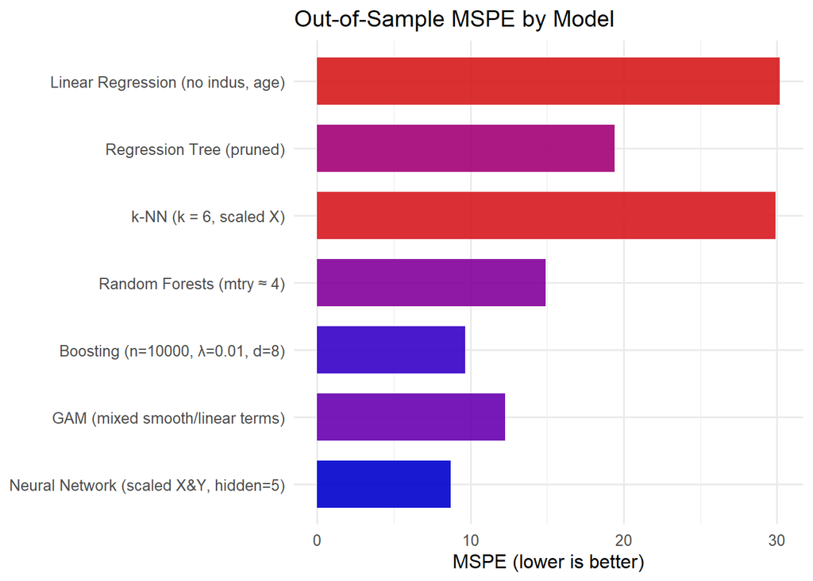

Figure 12: Out-of-sample MSPE for all seven models, where lower MSPE signifies better predictive power for new data. The Neural Network model has the lowest MSPE, and is therefore the best predictive model. Ensemble methods (Boosting, Random Forests) and the GAM consistently outperform the linear model and single regression tree.

# 12 Recommendations

Based on the model comparison and variable importance analyses, the following recommendations are made:

**1. Best Predictive Model:** The Neural Networks Model achieves the lowest Out-of-Sample MSPE, making it the top choice for prediction accuracy. Neural networks tend to be computationally expensive, so Boosting and Random Forest ensemble methods are good alternates, balancing accuracy and computational cost.

**2. Best Interpretable Model:** The GAM provides the best balance of flexibility and interpretability. Its smooth partial-effect plots clearly communicate how each predictor affects home `medv`, which can be valuable for actionable insights.

# 13 Discussion & Literature Comparison

The Boston Housing dataset has been extensively studied since Harrison & Rubinfeld (1978) first used it to estimate the willingness to pay for clean air using hedonic pricing methods. Their original OLS analysis identified `nox`, `rm`, `dis`, and `lstat` as key determinants—findings that align with our results.

**References:**

- Harrison, D. & Rubinfeld, D. (1978). Hedonic Housing Prices and the Demand for Clean Air. *Journal of Environmental Economics and Management*, 5(1), 81–102.
- Pace, R.K. & Gilley, O.W. (1997). Using the Spatial Configuration of the Data to Improve Estimation. *Journal of Real Estate Finance and Economics*, 14, 333–340.
- Grills, N. (2023). A comparative study of nonparametric spatial models. Master’s Report, Department of Statistics, Kansas State University.
- Belsley, D.A., Kuh, E. & Welsch, R.E. (1980). *Regression Diagnostics: Identifying Influential Data and Sources of Collinearity*. Wiley.